# Apache Spam Email Detection

- **Author**: [Andy Wang](https://www.linkedin.com/in/andy-wang-3b595a299/), Johns Hopkins University, Class of 2027
- **Github Repository**: https://github.com/sirandy3000/projects/tree/master/spam

## Abstract

> This Jupyter notebook contains my solution to a well-known machine learning problem: spam email detection. I sought out to correctly flag 1897 of 6047 emails uploaded to Apache SpamAssassin's public corpus in 2003 as spam. To solve this problem, I used natural language processing to create features from raw text/HTML. I first extracted texts from the email files, then cleaned them using regular expressions. I then engineered features using techniques such as Word-Count Vectorization and Principal Component Analysis. Finally, I performed cross-validation on several models and fine-tuned the hyperparameters of the best performer.

## Contents

1. Project Setup
2. Data Preprocessing
3. Modeling
4. Evaluation

## 1. Project Setup

In this section, I import required packages and download the dataset.

### 1.1) Package Import

```python
import os
import urllib
import tarfile

import collections
import email
import html
import nltk
import re
```

```python
import numpy as np
import pandas as pd
import matplotlib.pyplot as plt
from scipy.sparse import csr_matrix

from sklearn.base import BaseEstimator, TransformerMixin
from sklearn.decomposition import PCA
from sklearn.ensemble import GradientBoostingClassifier, RandomForestClassifier
from sklearn.linear_model import LogisticRegression
from sklearn.pipeline import Pipeline
from sklearn.svm import SVC

from sklearn.metrics import (
    accuracy_score, precision_recall_curve,
    precision_score, recall_score
)
from sklearn.model_selection import (
    cross_val_predict, cross_val_score,
    RandomizedSearchCV, train_test_split
)
```

### 1.2) Data Download

I download the dataset from the [Apache SpamAssassin public corpus](https://spamassassin.apache.org/old/publiccorpus/). The dataset arrives as a Tarfile, from which I extract the binary email files in `download_spam_data`. The files are organized into directories *easy_ham*, *easy_ham_2*, *hard_ham*, *spam*, and *spam_2* by default: I organize them into directories *ham* and *spam* in `organize_spam_data`.

```python
def download_spam_data():
    spam_root  = "http://spamassassin.apache.org/old/publiccorpus/"
    easy_ham   = spam_root + "20030228_easy_ham.tar.bz2"
    easy_ham_2 = spam_root + "20030228_easy_ham_2.tar.bz2"
    hard_ham   = spam_root + "20030228_hard_ham.tar.bz2"
    spam       = spam_root + "20030228_spam.tar.bz2"
    spam_2     = spam_root + "20030228_spam_2.tar.bz2"
    names = ["easy_ham", "easy_ham_2", "hard_ham", "spam", "spam_2"]
    urls  = [ easy_ham,   easy_ham_2,   hard_ham,   spam,   spam_2 ]

    for name, url in zip(names, urls):
        if not os.path.isdir(name): os.mkdir(name)
        dest = os.path.join(name, f"{name}.tar.bz2")
        urllib.request.urlretrieve(url, dest)
        with tarfile.open(dest) as tarball:
            tarball.extractall(path=".")
        try: os.remove(os.path.join(name, "cmds"))
        except FileNotFoundError: pass
        os.remove(dest)

def organize_spam_data():
    os.mkdir("ham")
    hams = ["easy_ham", "easy_ham_2", "hard_ham"]
    for d in hams:
        for f in os.listdir(d):
            os.replace(os.path.join(d, f), os.path.join("ham", f))
    for f in os.listdir("spam_2"):
        os.replace(os.path.join("spam_2", f), os.path.join("spam", f))
    for d in hams + ["spam_2"]:
        os.rmdir(d)

def load_spam_data():
    return [os.path.join( "ham", f) for f in os.listdir("ham")],\
           [os.path.join("spam", f) for f in os.listdir("spam")]
```

```python
download_spam_data()
organize_spam_data()
ham, spam = load_spam_data()
```

```python
print(f"The dataset consists of {len(ham)} ham files and {len(spam)} spam files.")
```

```
The dataset consists of 4150 ham files and 1897 spam files.
```

## 2. Data Preprocessing

In this section, I preprocess the dataset, including:

- Extracting texts from email files
- Splitting texts into training and evaluation sets
- Cleaning texts
- Converting word-counts into vectors
- Performing Principal Component Analysis

### 2.1) Text Extraction

The dataset currently consists of binary email files: I first extracted the emails from the files, then the texts from the emails. Many emails contained images, PGP signatures, and other items too difficult to include in this project, so I extracted only their plain-text or HTML portion.

```python
def parse_email(file):
    with open(file, "rb") as f:
        message = email.parser.BytesParser().parse(f)
    for content in message.walk():
        if content.get_content_type() in ["text/plain", "text/html"]:
            return content.get_payload()
    return ""
```

```python
ham  = [parse_email(f) for f in ham]
spam = [parse_email(f) for f in spam]
```

```python
print(ham[1])
```

```
Martin A posted:
Tassos Papadopoulos, the Greek sculptor behind the plan, judged that the
 limestone of Mount Kerdylio, 70 miles east of Salonika and not far from the
 Mount Athos monastic community, was ideal for the patriotic sculpture.

 As well as Alexander's granite features, 240 ft high and 170 ft wide, a
 museum, a restored amphitheatre and car park for admiring crowds are
planned
---------------------
So is this mountain limestone or granite?
If it's limestone, it'll weather pretty fast.

------------------------ Yahoo! Groups Sponsor ---------------------~-->
4 DVDs Free +s&p Join Now
http://us.click.yahoo.com/pt6YBB/NXiEAA/mG3HAA/7gSolB/TM
---------------------------------------------------------------------~->

To unsubscribe from this group, send an email to:
forteana-unsubscribe@egroups.com



Your use of Yahoo! Groups is subject to http://docs.yahoo.com/info/terms/
```

```python
print(spam[1])
```

```
1) Fight The Risk of Cancer!
http://www.adclick.ws/p.cfm?o=315&s=pk007

2) Slim Down - Guaranteed to lose 10-12 lbs in 30 days
http://www.adclick.ws/p.cfm?o=249&s=pk007

3) Get the Child Support You Deserve - Free Legal Advice
http://www.adclick.ws/p.cfm?o=245&s=pk002

4) Join the Web's Fastest Growing Singles Community
http://www.adclick.ws/p.cfm?o=259&s=pk007

5) Start Your Private Photo Album Online!
http://www.adclick.ws/p.cfm?o=283&s=pk007

Have a Wonderful Day,
Offer Manager
PrizeMama













If you wish to leave this list please use the link below.
http://www.qves.com/trim/?ilug@linux.ie%7C17%7C114258


--
Irish Linux Users' Group: ilug@linux.ie
http://www.linux.ie/mailman/listinfo/ilug for (un)subscription information.
List maintainer: listmaster@linux.ie
```

### 2.2) Train-Test Splitting

Before any further preprocessing, I split the dataset into a training set and an evaluation set. I wanted both sets to have equal proportions of spam vs non-spam emails, which I achieved by stratifying the split. I allocated 80% of the dataset for training, leaving 20% for evaluation.

```python
X = np.array(ham + spam, dtype="object")
y = np.array([0] * len(ham) + [1] * len(spam))

X_train, X_test, y_train, y_test = train_test_split(
    X, y, test_size=0.2, stratify=y, random_state=42
)
```

### 2.3) Text Cleaning

Before the texts can be analyzed, they must be cleaned; I created a transformer uses regular expressions to remove/replace various unwanted elements of each text:

`lowercase`: converts all letters to lowercase  
`lemmatize`: extracts the roots of words (i.e. *cleans*, *cleaning*, and *cleaned* become *clean*)  
`remove_escapes`: unescapes HTML special characters (i.e. *&gt* becomes *>*)  
`remove_head`: removes the HTML head section  
`remove_html`: removes all HTML tags  
`remove_punctuation`: removes all punctuation  
`replace_hyperlinks`: replaces hyperlinks with *HYPERLINK*  
`replace_numbers`: replaces numbers with *NUMBER*  
`replace_spacing`: removes unnecessary spaces, tabs, and newlines  
`replace_urls`: replaces urls with *URL*

```python
class TextCleaner(BaseEstimator, TransformerMixin):
    def __init__(self,
                 lowercase          = True,
                 lemmatize          = True,
                 remove_escapes     = True,
                 remove_head        = True,
                 remove_html        = True,
                 remove_punctuation = True,
                 replace_hyperlinks = True,
                 replace_numbers    = True,
                 replace_spacing    = True,
                 replace_urls       = True
                ):
        self.lowercase          = lowercase
        self.lemmatize          = lemmatize
        self.remove_escapes     = remove_escapes
        self.remove_head        = remove_head
        self.remove_html        = remove_html
        self.remove_punctuation = remove_punctuation
        self.replace_hyperlinks = replace_hyperlinks
        self.replace_numbers    = replace_numbers
        self.replace_spacing    = replace_spacing
        self.replace_urls       = replace_urls

    def fit(self, X, y=None):
        return self

    def transform(self, X):
        X_clean = []
        for text in X:
            if self.lowercase:
                text = text.lower()
            if self.remove_head:
                text = re.sub("<head>.*</head>", "", text, flags=re.S)
            if self.replace_hyperlinks:
                text = re.sub(r"<a\s.*?>", " HYPERLINK ", text, flags=re.S)
            if self.replace_urls:
                text = re.sub(r"(https?://)?[\w.-]+[.][^\s]+", " URL ", text)
            if self.remove_escapes:
                text = html.unescape(text)
            if self.remove_html:
                text = re.sub("<.*?>", " ", text, flags=re.S)
            if self.replace_numbers:
                text = re.sub(r"\d+([,.:e-]\d+)*", " NUMBER ", text)
            if self.remove_punctuation:
                text = re.sub(r"([^\w\s]|_)+", "", text)
            if self.replace_spacing:
                text = re.sub(r"(\s*\n)+", "\n", text)
                text = re.sub(r"\s{2,}", " ", text)
            if self.lemmatize:
                lemmatizer = nltk.stem.wordnet.WordNetLemmatizer()
                text = " ".join([lemmatizer.lemmatize(word) for word in text.split()])
            X_clean.append(text)
        return np.array(X_clean)
```

### 2.4) Word Counts

Next, I created a second transformer that takes cleaned texts as input and returns a map from each word to the number of times it appears. For example, the text *"the man and the woman and the boy"* becomes `{"the": 3, "and": 2, "man": 1, "woman": 1, "boy": 1}`.

```python
class WordCounter(BaseEstimator, TransformerMixin):
    def __init__(self):
        pass
    def fit(self, X, y=None):
        return self
    def transform(self, X):
        X_counts = []
        for text in X:
            X_counts.append(collections.Counter(text.split()))
        return np.array(X_counts)
```

### 2.5) Vectorization

```python
class CountVectorizer(BaseEstimator, TransformerMixin):
    def __init__(self, vocabulary_size=1000):
        self.vocabulary_size = vocabulary_size

    def fit(self, X, y=None):
        total_count = collections.Counter()
        for word_count in X:
            for w, c in word_count.items():
                total_count[w] += c
        most_common = total_count.most_common(self.vocabulary_size)
        self.vocabulary = {w: i+1 for i, (w, c) in enumerate(most_common)}
        return self

    def transform(self, X):
        data, rows, cols = [], [], []
        for row, word_count in enumerate(X):
            for w, c in word_count.items():
                data.append(c)
                rows.append(row)
                cols.append(self.vocabulary.get(w, 0))
        return csr_matrix((data, (rows, cols)), (X.shape[0], self.vocabulary_size+1))
```

### 2.6) Final Steps

Depending on the vocabulary size, `CountVectorizer` may return extremely large, sparse matrices that dramatically slow computation during modeling. Thus, as the last preprocessing step, I performed Principal Component Analysis on the matrix, retaining 99% of its explained variance but dramatically reducing its number of features. Finally, I assembled all steps into a single pipeline.

```python
preprocessing = Pipeline([
    ("clean", TextCleaner()),
    ("count", WordCounter()),
    ("vectorize", CountVectorizer()),
    ("pca", PCA(0.99, svd_solver="covariance_eigh"))
])
X_train_preprocessed = preprocessing.fit_transform(X_train)
```

```python
print("Number of features before PCA:", preprocessing[2].vocabulary_size)
print("Number of features after PCA:", preprocessing[3].n_components_)
```

```
Number of features before PCA: 1000
Number of features after PCA: 8
```

## 3. Modeling

In this section, I trained several models, then tuned the hyperparameters of the best-performing model.

### 3.1) Initial Models

Using 3-fold cross-validation, I first trained and evaluated several models, listed below, with default parameters. The best-performing model, i.e. that with the highest accuracy, was Random Forest Classification.

```python
rs = {"random_state": 42}

models = {
    "Logistic":       LogisticRegression(**rs),
    "SVC_linear":     SVC(kernel="linear", **rs),
    "SVC_poly":       SVC(kernel="poly", **rs),
    "SVC_rbf":        SVC(kernel="rbf", **rs),
    "SVC_sigmoid":    SVC(kernel="sigmoid", **rs),
    "Random_Forest":  RandomForestClassifier(**rs),
    "Gradient_Boost": GradientBoostingClassifier(**rs)
}
```

```python
cv_scores = []
for name, model in models.items():
    cvs = cross_val_score(
        model, X_train_preprocessed, y_train,
        cv=3, scoring="accuracy", n_jobs=-1
    )
    cv_scores.append([name, cvs.mean(), cvs.std()])
```

```python
cv_scores = pd.DataFrame(cv_scores, columns=["model", "mean_acc", "std_acc"])
cv_scores.sort_values("mean_acc", ascending=False, inplace=True)
cv_scores.reset_index(drop=True, inplace=True)
cv_scores
```

|  | model | mean_acc | std_acc |
| --- | --- | --- | --- |
| 0 | Random_Forest | 0.904278 | 0.007766 |
| 1 | Gradient_Boost | 0.873681 | 0.007684 |
| 2 | Logistic | 0.820342 | 0.006377 |
| 3 | SVC_linear | 0.816000 | 0.006931 |
| 4 | SVC_rbf | 0.729170 | 0.005430 |
| 5 | SVC_poly | 0.705601 | 0.005841 |
| 6 | SVC_sigmoid | 0.653715 | 0.021861 |

### 3.2) Hyperparameter Tuning

Using randomized search, I tuned:

- The number of features to consider when splitting each Decision Tree node
- The vocabulary size for the CountVectorizer

```python
pipeline = Pipeline([
    ("preprocessing", preprocessing),
    ("model", RandomForestClassifier(random_state=42))
])
parameters = {
    "model__max_features": np.linspace(0.1, 0.3, 5),
    "preprocessing__vectorize__vocabulary_size": np.logspace(2, 4, 5).astype(int)
}
```

```python
random_search = RandomizedSearchCV(
    pipeline, parameters, n_iter=5, cv=3,
    scoring="accuracy", n_jobs=-1, random_state=42
)
random_search.fit(X_train, y_train)
```

```
RandomizedSearchCV(cv=3,
                   estimator=Pipeline(steps=[('preprocessing',
                                              Pipeline(steps=[('clean',
                                                               TextCleaner()),
                                                              ('count',
                                                               WordCounter()),
                                                              ('vectorize',
                                                               CountVectorizer()),
                                                              ('pca',
                                                               PCA(n_components=0.99,
                                                                   svd_solver='covariance_eigh'))])),
                                             ('model',
                                              RandomForestClassifier(random_state=42))]),
                   n_iter=5, n_jobs=-1,
                   param_distributions={'model__max_features': array([0.1 , 0.15, 0.2 , 0.25, 0.3 ]),
                                        'preprocessing__vectorize__vocabulary_size': array([  100,   316,  1000,  3162, 10000])},
                   random_state=42, scoring='accuracy')
```

```python
old_acc = cv_scores.loc[0, "mean_acc"]
new_acc = random_search.best_score_
reduction = 1 - (1 - new_acc) / (1 - old_acc)

print(f"Accuracy before tuning: {old_acc:.3%}")
print(f"Accuracy after tuning: {new_acc:.3%}")
print(f"Eliminated {reduction:.3%} of errors")
```

```
Accuracy before tuning: 90.428%
Accuracy after tuning: 93.859%
Eliminated 35.849% of errors
```

```python
final_model = random_search.best_estimator_
random_search.best_params_
```

```
{'preprocessing__vectorize__vocabulary_size': 3162,
 'model__max_features': 0.15}
```

### 3.3) Precision-Recall Tradeoff

I prefer a strict spam email classifier, one that flags as many spam emails as possible, at the risk of occasionally flagging a harmless email; as *spam* is the positive class, this means I prefer high recall over high precision. I lowered the probability threshold to flag an email from 50% to 29%, and the model's recall on the validation folds increased from 88% to 95% without losing too much precision.

```python
y_probas = cross_val_predict(
    final_model, X_train, y_train,
    cv=3, n_jobs=-1, method="predict_proba"
)
precisions, recalls, thresholds =\
    precision_recall_curve(y_train, y_probas[:, 1])
```

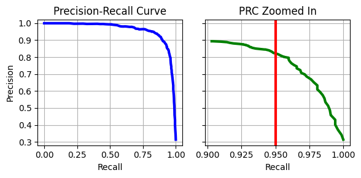

```python
prc_fig, prc_axs = plt.subplots(ncols=2, figsize=(6, 3))

kwargs = {"yticks": np.linspace(0.3, 1, 8), "ylim": (0.28, 1.02)}

prc_axs[0].plot(recalls, precisions, "b-", linewidth=3)
prc_axs[0].set(title="Precision-Recall Curve", xlabel="Recall", ylabel="Precision", **kwargs)
prc_axs[0].grid()

prc_axs[1].plot(recalls[recalls >= 0.9], precisions[recalls >= 0.9], "g-", linewidth=3)
prc_axs[1].set(title="PRC Zoomed In", xlabel="Recall", yticklabels=[], **kwargs)
prc_axs[1].vlines(0.95, 0.28, 1.02, color="r", linewidth=3)
prc_axs[1].grid()

plt.tight_layout()
plt.show()
```

```python
y_pred = (y_probas[:, 1] >= 0.5)

old_precision = precision_score(y_train, y_pred)
old_recall    = recall_score(y_train, y_pred)
old_threshold = 0.5

new_recall    = recalls[recalls >= 0.95][-1]
new_precision = precisions[recalls >= 0.95][-1]
new_threshold = thresholds[recalls[:-1] >= 0.95][-1]
```

```python
print("Old Recall:    {:.3%}".format(old_recall))
print("Old Precision: {:.3%}".format(old_precision))
print("Old Threshold: {:.3%}".format(old_threshold), "\n")

print("New Recall:    {:.3%}".format(new_recall))
print("New Precision: {:.3%}".format(new_precision))
print("New Threshold: {:.3%}".format(new_threshold))
```

```
Old Recall:    88.398%
Old Precision: 91.975%
Old Threshold: 50.000%

New Recall:    95.188%
New Precision: 81.767%
New Threshold: 29.000%
```

## 4. Evaluation

In this section, I evaluated the final model on the evaluation set. The model performed slightly better on the evaluation set than on the validation folds, indicating that it generalizes well and did not overfit.

```python
y_probas = final_model.predict_proba(X_test)
y_pred = (y_probas[:, 1] >= new_threshold)
final_recall = recall_score(y_test, y_pred)
gen_error = 1 - (1 - final_recall) / (1 - new_recall)

print(f"Recall on evaluation set: {final_recall:.3%}")
print(f"The final model performed {gen_error:.3%} better on the evaluation set.")
```

```
Recall on evaluation set: 96.053%
The final model performed 17.970% better on the evaluation set.
```